# Bulk RNA-seq: Hands-On Analysis

Human NK cells, GSE191074

## Before you start

### 0.0.1 How to run this document

Each grey block below is a **chunk**. Click the green ▶ at its top-right to run it. Output appears directly underneath.

**Three things that will save you**

**Run chunks in order, from the top.** Later ones use objects the earlier ones create.

**If you lose your place**, put the cursor in the first chunk and use **Run → Run All Chunks Below**. Faster than hunting for where you were.

**If a chunk does nothing when you click ▶**, look at the Console. If the prompt is `+` rather than `>`, press Esc. If that is not it, switch the editor from Visual to Source using the toggle above this pane.

Everything here starts from a count matrix that `nf-core/rnaseq` has already produced. Nothing here aligns reads.

You need these packages. In the workshop environment they are already installed.

```r
library(DESeq2)     # the analysis
library(ggplot2)    # plots
library(dplyr)      # handling tables
library(stringr)    # handling text
library(tidyr)      # reshaping tables
library(ggrepel)    # labels that do not overlap, for the volcano plot
```

**Three tools, pick one**

You will see **DESeq2**, **edgeR** and **limma** in papers doing the same job. They are alternatives, not a pipeline: each takes counts and returns a ranked list of genes, and they agree on most of them.

This document uses **DESeq2** throughout. `edgeR` appears exactly once below, for a normalization helper, and is called as `edgeR::cpm()` rather than loaded, so it is obvious where it is being used.

If you have inherited a script that loads all three, that is usually history rather than necessity.

### 0.0.2 The experiment

Human NK cells from healthy donors, split into five arms, three biological replicates each.

| Arm | What was in the well | Why it is there |
| --- | --- | --- |
| `NK-only` | NK cells alone | Baseline |
| `NK-PGE2` | + prostaglandin E2 | Does the soluble factor alone suppress NK cells? |
| `NK-K562` | + K562, the standard NK target | Positive control: does the NK response work at all? |
| `NK-Blasts` | + primary AML blasts | Do AML blasts activate NK cells? |
| `NK-Blasts-K562` | + both | Can blasts suppress a response that normally works? |

Fifteen samples, public, GEO accession GSE191074. The five arms are not a list of treatments; each one answers a specific question, and the last is the key experiment.

K562 is worth a word, because it appears in two arms and is not a treatment like the others. It carries no HLA class I, so NK cells are not held back by their inhibitory receptors and kill it readily. That makes it the standard way to ask whether a batch of NK cells is working: add K562, then measure degranulation, cytokine production and killing. Here it plays that role twice — once on untreated NK cells to show what an intact response looks like, and once on blast-exposed cells to ask whether the response survives.

# 1 Setting up

## 1.1 Load the counts

The count table lives in the `data` folder of this project.

```r
count_file <- "data/GSE191074_CountTable.txt.gz"

if (!file.exists(count_file)) {
  stop("Cannot find the count table.\n",
       "Open bulk-rnaseq-course.Rproj first, then reopen this document.\n",
       "Working directory is currently: ", getwd())
}

counts <- read.delim(count_file, row.names = 1, check.names = FALSE)
counts <- as.matrix(counts)

dim(counts)
```

```
#> [1] 35598    15
```

**If that stopped with an error**

R is looking in the wrong folder. Open `bulk-rnaseq-course.Rproj` by double-clicking it, which starts RStudio in the right place, then open this document again from the Files pane.

Working in a project rather than loose files is worth the habit: every path is relative to the project folder, so the same code runs on anyone’s machine without editing.

35,598 genes down the side, 15 samples across the top. The top-left corner:

```r
counts[1:5, 1:4]
```

```
#>          NK-only-BR1.fastq NK-only-BR2.fastq NK-only-BR3.fastq
#> A1BG                     0                 2                 4
#> A1BG-AS1                 7                 2                10
#> A1CF                     0                 0                 1
#> A2M                      1                11                 1
#> A2M-AS1                  3                 4                 4
#>          NK-PGE2-BR1.fastq
#> A1BG                     2
#> A1BG-AS1                 2
#> A1CF                     0
#> A2M                      0
#> A2M-AS1                  2
```

Every number is a raw read count. Not expression, not normalized, not a fold change.

## 1.2 Load the sample sheet

The model needs to know which sample is which. That information lives in a separate file — the sample sheet — with one row per sample.

```r
design_df <- read.csv("data/sample_sheet.csv") |>
  mutate(
    condition = factor(condition,
                       levels = c("NK-only", "NK-PGE2", "NK-K562",
                                  "NK-Blasts", "NK-Blasts-K562")),
    replicate = factor(replicate)
  )

design_df
```

```
#>                      sample geo_accession      condition replicate
#> 1         NK-only-BR1.fastq    GSM5738329        NK-only       BR1
#> 2         NK-only-BR2.fastq    GSM5738330        NK-only       BR2
#> 3         NK-only-BR3.fastq    GSM5738331        NK-only       BR3
#> 4         NK-PGE2-BR1.fastq    GSM5738332        NK-PGE2       BR1
#> 5         NK-PGE2-BR2.fastq    GSM5738333        NK-PGE2       BR2
#> 6         NK-PGE2-BR3.fastq    GSM5738334        NK-PGE2       BR3
#> 7       NK-Blasts-BR1.fastq    GSM5738335      NK-Blasts       BR1
#> 8       NK-Blasts-BR2.fastq    GSM5738336      NK-Blasts       BR2
#> 9       NK-Blasts-BR3.fastq    GSM5738337      NK-Blasts       BR3
#> 10 NK-Blasts-K562-BR1.fastq    GSM5738338 NK-Blasts-K562       BR1
#> 11 NK-Blasts-K562-BR2.fastq    GSM5738339 NK-Blasts-K562       BR2
#> 12 NK-Blasts-K562-BR3.fastq    GSM5738340 NK-Blasts-K562       BR3
#> 13        NK-K562-BR1.fastq    GSM5738341        NK-K562       BR1
#> 14        NK-K562-BR2.fastq    GSM5738342        NK-K562       BR2
#> 15        NK-K562-BR3.fastq    GSM5738343        NK-K562       BR3
```

`mutate()` adds or changes a column. Here it turns two text columns into **factors**, which is R’s type for a categorical variable.

The `levels` argument matters more than it looks. The first level — `NK-only` — becomes the **reference** that everything else is compared against. Change the order and you change what every fold change means.

**Where this sheet came from**

The authors deposited the counts and the sample names. GEO’s metadata for this series records `donor: healthy volunteer` for all fifteen samples, with no donor identifier and no condition field — the condition exists only inside the sample title.

So this sheet was built from those names. The condition and replicate labels are the authors’; arranging them into a table is ours.

Reconstructing a design sheet like this is a normal part of reusing public data. The code that did it is in the appendix.

**Check this table every single time**

The count matrix and the sample table are two separate objects. Nothing stops them being lined up wrong, and if they are, the groups are silently swapped and every result below is wrong.

Run the next chunk to confirm the order matches before going further.

```r
identical(colnames(counts), as.character(design_df$sample))
```

```
#> [1] TRUE
```

```r
table(design_df$condition, design_df$replicate)
```

```
#>
#>                  BR1 BR2 BR3
#>   NK-only          1   1   1
#>   NK-PGE2          1   1   1
#>   NK-K562          1   1   1
#>   NK-Blasts        1   1   1
#>   NK-Blasts-K562   1   1   1
```

One sample in every cell. This is the design grid from the slides, filled in: every condition appears once in every replicate batch, which is what makes the batch effect separable from the treatment effect.

# 2 Checking the samples

Before testing anything, confirm the samples are what the labels say and contain only the cells they should.

Both checks are plots of a handful of genes. No special software.

## 2.1 Sequencing depth

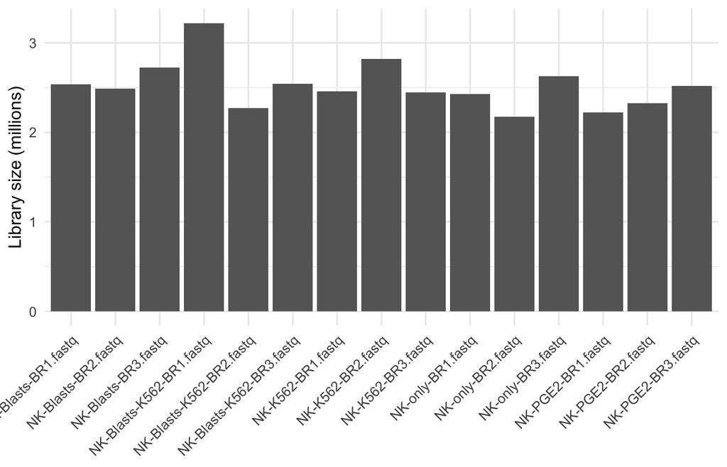

```r
lib <- tibble(sample   = design_df$sample,
              millions = colSums(counts) / 1e6)

ggplot(lib, aes(x = sample, y = millions)) +
  geom_col(fill = "grey40") +
  labs(x = NULL, y = "Library size (millions)") +
  theme_minimal(base_size = 12) +
  theme(axis.text.x = element_text(angle = 45, hjust = 1))
```

The libraries differ, which is normal, and it is why raw counts cannot be compared directly.

## 2.2 Normalize for looking at

```r
# the one place edgeR is used: its cpm() is a convenient way to get
# normalized log counts for plotting. DESeq2 does everything else.
dge  <- edgeR::DGEList(counts)
dge  <- edgeR::calcNormFactors(dge)      # the composition correction
lcpm <- edgeR::cpm(dge, log = TRUE, prior.count = 2)
```

`calcNormFactors()` is edgeR’s version of the composition correction — the same job DESeq2’s size factors do later.

`prior.count = 2` adds a small constant before logging, so genes with zero counts give a finite number instead of negative infinity.

**Two objects, two purposes**

`lcpm` is normalized and logged, and is used **only for plotting** in this section.

`counts` stays raw, and is what goes into DESeq2 later. Keep them straight — handing `lcpm` to DESeq2 would silently produce wrong results.

**Do not filter before a contamination check**

Filtering removes genes that are lowly expressed, which is exactly what contaminant genes look like. Filter first and the evidence is gone, and the samples look clean.

Note this used the **unfiltered** matrix.

## 2.3 Why we log

Same data, same normalization, two scales. One box per sample.

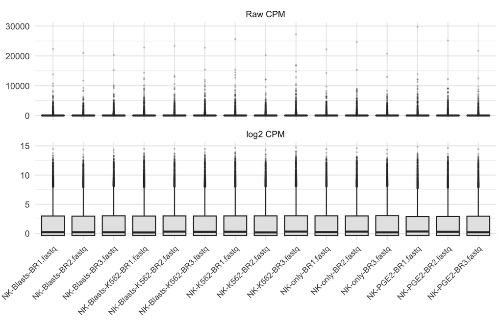

```r
cpm_raw <- edgeR::cpm(dge)      # normalized, but not logged

bind_rows(
  as_tibble(cpm_raw) |>
    pivot_longer(everything(), names_to = "sample", values_to = "value") |>
    mutate(scale = "Raw CPM"),
  as_tibble(lcpm) |>
    pivot_longer(everything(), names_to = "sample", values_to = "value") |>
    mutate(scale = "log2 CPM")
) |>
  mutate(scale = factor(scale, levels = c("Raw CPM", "log2 CPM"))) |>
  ggplot(aes(x = sample, y = value)) +
  geom_boxplot(fill = "grey90", outlier.size = 0.3, outlier.alpha = 0.2) +
  facet_wrap(~ scale, scales = "free_y", ncol = 1) +
  labs(x = NULL, y = NULL) +
  theme_minimal(base_size = 11) +
  theme(axis.text.x = element_text(angle = 45, hjust = 1, size = 8))
```

The top panel is why we log. Expression spans several orders of magnitude: most genes sit near zero while a handful run into the thousands, so every box is squashed flat against the bottom and the plot tells you nothing.

The bottom panel is the same numbers on a log scale. Now the boxes have visible spread and the samples can be compared.

This is also a QC plot in its own right: the boxes should line up across samples. One sitting noticeably higher or lower than the rest had something go wrong in library prep.

**Warning**

This is for **looking at**, not for testing. DESeq2 gets raw counts.

## 2.4 Where do the samples sit relative to each other?

Principal component analysis reduces 35,000 genes to a couple of axes that capture most of the variation. It is the fastest way to spot an outlier, a batch effect, or samples that are not where you expect.

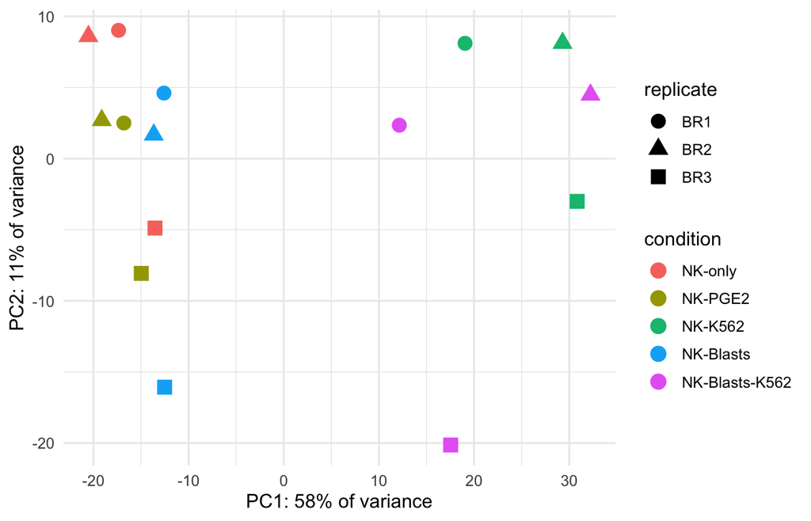

```r
# use the 500 most variable genes - the ones carrying the structure
top_var <- lcpm[order(apply(lcpm, 1, var), decreasing = TRUE)[1:500], ]

pca <- prcomp(t(top_var))
pct <- round(100 * pca$sdev^2 / sum(pca$sdev^2))

pca_df <- as_tibble(pca$x[, 1:2]) |>
  mutate(condition = design_df$condition,
         replicate = design_df$replicate)

ggplot(pca_df, aes(x = PC1, y = PC2, colour = condition, shape = replicate)) +
  geom_point(size = 4) +
  labs(x = paste0("PC1: ", pct[1], "% of variance"),
       y = paste0("PC2: ", pct[2], "% of variance")) +
  theme_minimal(base_size = 12)
```

Two things to look for. Do samples group by **condition**, which is what you hope? Or do they group by **replicate**, which would mean batch dominates biology? And is any single sample sitting far away from everything else?

## 2.5 A helper for marker panels

```r
score_panel <- function(genes, mat) {
  present <- intersect(genes, rownames(mat))
  if (length(present) == 0) return(rep(NA_real_, ncol(mat)))
  colMeans(mat[present, , drop = FALSE])
}
```

Averaging several markers is more robust than trusting one gene.

## 2.6 Check 1: do the sex genes agree?

`XIST` is expressed from the inactive X, so it is high in female samples and near zero in male ones. Y-linked genes are the reverse.

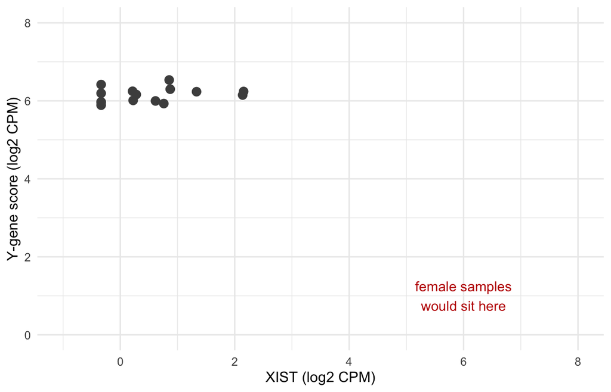

```r
y_genes <- c("RPS4Y1", "UTY", "KDM5D", "DDX3Y", "EIF1AY", "USP9Y")

sex <- tibble(
  sample  = colnames(lcpm),
  xist    = score_panel("XIST", lcpm),
  y_score = score_panel(y_genes, lcpm)
)

ggplot(sex, aes(x = xist, y = y_score)) +
  geom_point(size = 3, colour = "grey30") +
  expand_limits(x = c(-1, 8), y = c(0, 8)) +
  annotate("text", x = 6, y = 1, label = "female samples\nwould sit here",
           colour = "#C00000", size = 4) +
  labs(x = "XIST (log2 CPM)", y = "Y-gene score (log2 CPM)") +
  theme_minimal(base_size = 12)
```

```r
counts[c("XIST", "RPS4Y1", "DDX3Y"), 1:6]
```

```
#>        NK-only-BR1.fastq NK-only-BR2.fastq NK-only-BR3.fastq NK-PGE2-BR1.fastq
#> XIST                   0                 2                 0                 0
#> RPS4Y1               967              1018              1174               869
#> DDX3Y                200               197               274               353
#>        NK-PGE2-BR2.fastq NK-PGE2-BR3.fastq
#> XIST                   0                 1
#> RPS4Y1               993               996
#> DDX3Y                399               375
```

XIST is 0 to 2 reads, `RPS4Y1` around a thousand. Not ambiguous.

**Why this works without any metadata**

This is an **internal consistency** check. Even with no recorded sex anywhere, samples should form two tight clusters with nothing in between.

With recorded sex you get a second, stronger check: does the data agree with the records? A disagreement means a sample was swapped somewhere between the bench and the sequencer.

**A point in the middle** usually means two samples were mixed.

Worth recording donor sex in your sample sheet for exactly this reason. It costs nothing and gives a free integrity check on every experiment.

## 2.7 Check 2: is anything else in these samples?

These were sorted after co-culture. Sorting is good, not perfect.

Blood carryover is the usual worry in any primary cell prep, so start there: red blood cell genes should be absent from a pure lymphocyte population.

```r
panels <- list(
  nk        = c("NCAM1", "KLRD1", "KLRF1", "NCR1", "NKG7", "GNLY", "PRF1"),
  t_cell    = c("TRAC"),
  monocyte  = c("CD14", "LYZ", "S100A8", "S100A9", "VCAN", "FCN1"),
  b_cell    = c("MS4A1", "CD79A"),
  erythroid = c("HBG1", "HBG2", "HBZ", "GATA1", "GYPA", "KLF1"),
  platelet  = c("PPBP", "PF4")
)

scores <- as_tibble(lapply(panels, score_panel, mat = lcpm)) |>
  mutate(sample    = colnames(lcpm),
         condition = design_df$condition)
```

**Choose markers the other cell type cannot fake**

`CD2` would be a bad T-cell marker here, because NK cells express it too. `TRAC` is a good one: NK cells do not rearrange a T-cell receptor, so any signal is genuine carryover.

The same logic applies to every panel. Pick genes your cells cannot possibly make.

First, confirm these are NK cells at all:

```r
round(range(scores$nk), 1)
```

```
#> [1] 9.1 9.7
```

NK markers are high in every sample, as they should be.

**Before running the next chunk, predict what you expect** from the other panels. These were all sorted NK cells.

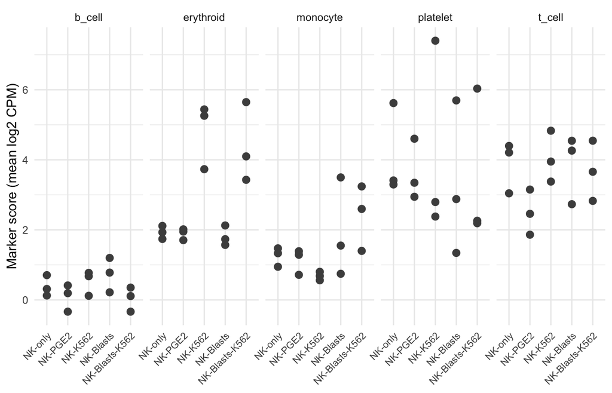

```r
scores |>
  pivot_longer(cols = all_of(setdiff(names(panels), "nk")),
               names_to = "panel", values_to = "score") |>
  ggplot(aes(x = condition, y = score)) +
  geom_point(size = 2.5, colour = "grey30") +
  facet_wrap(~ panel, nrow = 1) +
  labs(x = NULL, y = "Marker score (mean log2 CPM)") +
  theme_minimal(base_size = 11) +
  theme(axis.text.x = element_text(angle = 45, hjust = 1, size = 8))
```

```r
scores |>
  group_by(condition) |>
  summarise(erythroid = round(mean(erythroid), 2))
```

```
#> # A tibble: 5 × 2
#>   condition      erythroid
#>   <fct>              <dbl>
#> 1 NK-only             1.93
#> 2 NK-PGE2             1.89
#> 3 NK-K562             4.81
#> 4 NK-Blasts           1.81
#> 5 NK-Blasts-K562      4.39
```

NK cells are lymphocytes and do not make hemoglobin. This is RNA from target cells that survived sorting.

## 2.8 Which hemoglobin tells you the source

The check started as a search for blood carryover. The pattern says it is not blood.

```r
counts[c("HBG2", "HBZ", "HBG1", "HBB"),
       c("NK-only-BR1.fastq", "NK-only-BR2.fastq",
         "NK-K562-BR1.fastq", "NK-K562-BR2.fastq")]
```

```
#>      NK-only-BR1.fastq NK-only-BR2.fastq NK-K562-BR1.fastq NK-K562-BR2.fastq
#> HBG2                56                43               400              1486
#> HBZ                 30                32               177               934
#> HBG1                 4                 8                27               105
#> HBB                  3                 2                 2                 5
```

Humans make different globins at different life stages:

| Gene | Stage |
| --- | --- |
| `HBZ` | Embryonic (zeta) |
| `HBG1`, `HBG2` | Fetal (gamma) |
| `HBB` | Adult (beta) |

Fetal and embryonic globin go up roughly twenty-fold. Adult globin does not move.

Blood carryover would look the opposite: adult globin dominant, embryonic silent. K562 is a human erythroleukemia line with the globin profile of embryonic and fetal erythroid progenitors — zeta and gamma, with very little adult beta.

**The transferable part**

The marker pattern identified the contaminating cell type, not just its presence. Picking genes that differ between the candidate sources turns a yes/no check into an answer.

We will come back to whether any of this changes the results.

# 3 A first comparison

The simplest comparison in the dataset: **NK + PGE2 versus NK alone**. Neither arm had K562 in it, so the carryover found above is not involved.

## 3.1 Set up the model

```r
dds <- DESeqDataSetFromMatrix(
  countData = counts,
  colData   = design_df,
  design    = ~ replicate + condition
)
```

Three things go in: the raw counts, the sample table, and the formula.

Reading `~ replicate + condition` right to left: compare the conditions, after accounting for differences between replicate batches.

**Why the variable of interest goes last**

The model fit is identical whichever order you write the terms in. What changes is the default: `results()` with no arguments returns a comparison for the **last** variable in the formula.

Put `condition` last and the default is what you want.

## 3.2 Filter low-count genes

```r
keep <- rowSums(counts(dds) >= 10) >= 3
table(keep)
```

```
#> keep
#> FALSE  TRUE
#> 24082 11516
```

```r
dds <- dds[keep, ]
```

A gene needs at least 10 reads in at least 3 samples. The thresholds are conventional rather than magic: 10 reads is roughly where a count starts carrying usable information, and 3 matches the smallest group size, so a gene expressed in only one condition still survives.

Genes below the cutoff carry no usable signal, and testing them costs power through multiple-testing correction.

This is where filtering belongs — after the contamination check, not before.

## 3.3 Run it

```r
dds <- DESeq(dds)
```

The messages describe real steps. `estimating size factors` is the composition correction. `gene-wise dispersion estimates` followed by `final dispersion estimates` is the borrowing-across-genes step.

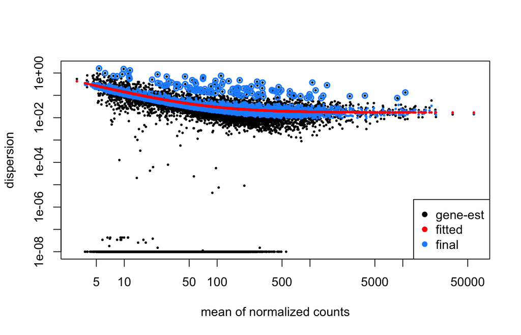

```r
plotDispEsts(dds)
```

The plot from the slides: each dot is a gene, black for its own noisy estimate, blue for the final value after being pulled toward the red trend. The genes strung along the bottom had replicates that landed almost identically by chance; shrinkage pulls them up to something plausible.

## 3.4 What the model fitted

```r
resultsNames(dds)
```

```
#> [1] "Intercept"                           "replicate_BR2_vs_BR1"
#> [3] "replicate_BR3_vs_BR1"                "condition_NK.PGE2_vs_NK.only"
#> [5] "condition_NK.K562_vs_NK.only"        "condition_NK.Blasts_vs_NK.only"
#> [7] "condition_NK.Blasts.K562_vs_NK.only"
```

Each of these is a number the model estimated for every gene. The `replicate` ones are the batch effects being accounted for. The `condition` ones are the comparisons.

**Think of it as elevation above sea level**

The model picks one condition as sea level — the first factor level, `NK-only` — and records how far every other condition sits above or below it. Those recorded heights are what `resultsNames()` lists.

| Question | How DESeq2 answers | What you write |
| --- | --- | --- |
| How high is Denver? | reads off a stored number | `name = "condition_NK.K562_vs_NK.only"` |
| How much higher is Denver than Houston? | subtracts two stored numbers | `contrast = c("condition","NK-K562","NK-PGE2")` |

Both are instant; nothing is refitted. `name` works only for comparisons against the reference. `contrast` works for any pair, and says what is being compared without looking up a name, which is why this document uses it.

One catch: `lfcShrink(type = "apeglm")` needs `coef`, which is the same string as `name`. So for shrinkage you do need the name from the list above.

Note the names are mangled — `NK-PGE2` becomes `NK.PGE2`. That is what the message about characters other than letters, numbers, `_` and `.` during `DESeq()` was warning about.

## 3.5 Results

```r
res_pge2 <- results(dds, contrast = c("condition", "NK-PGE2", "NK-only"))

sum(res_pge2$padj < 0.05, na.rm = TRUE)
```

```
#> [1] 1176
```

```r
as.data.frame(res_pge2) |>
  tibble::rownames_to_column("gene") |>
  filter(!is.na(padj)) |>
  arrange(padj) |>
  select(gene, baseMean, log2FoldChange, padj) |>
  head(10)
```

```
#>        gene  baseMean log2FoldChange         padj
#> 1     KRT86  221.8974       3.062354 2.586843e-42
#> 2      RGS2  436.8069       2.646441 1.802966e-29
#> 3      CREM 1689.2854       2.475200 2.836129e-28
#> 4    TSPYL2  234.1603       2.571689 1.640091e-20
#> 5      CCL5 5310.2470      -1.183812 4.412026e-17
#> 6     DUSP2  882.4346       1.550132 4.412026e-17
#> 7     RAMP1  763.3213       1.416358 4.412026e-17
#> 8    CEMIP2  320.1831       1.466141 2.825641e-15
#> 9     NOP58  704.4527       1.516530 2.245133e-14
#> 10 FAM177A1  509.9800       1.469043 3.010722e-14
```

`results()` returns a `DESeqResults` object rather than a data frame, so `as.data.frame()` comes first. `filter()` keeps rows, `arrange()` sorts, `select()` picks columns.

**One model, many comparisons**

`DESeq()` fits the model once. `results()` then forms a particular contrast from the stored coefficients, computes its p-values, and applies its own filtering and multiple-testing correction.

So you can pull any comparison out of the same fit:

```r
results(dds, contrast = c("condition", "NK-K562",   "NK-only"))
results(dds, contrast = c("condition", "NK-Blasts", "NK-only"))
```

Each one gets its own `padj`, corrected independently.

**Why not analyze two conditions at a time?**

It is tempting to subset to the two arms you care about and fit a smaller model. That throws away information.

With all 15 samples and `~ replicate + condition`, the model fits 7 coefficients, leaving **8 residual degrees of freedom** to estimate each gene’s dispersion. Subset to 6 samples and you have **2**.

Dispersion is what the p-values hinge on, so that is a real loss of power.

The joint model assumes dispersion is similar across conditions. If one group is far more variable than the rest — patient-derived material is the usual case — that assumption breaks and splitting is justified.

**Why some genes have `padj = NA`**

DESeq2 filters out genes too lowly expressed to reach significance, so they are excluded from the multiple-testing correction rather than counted against it. Those get `padj = NA`. It is not an error, and it increases power for everything else.

## 3.6 Does the answer make sense?

Third in the list is **CREM**, the cAMP response element modulator.

PGE2 signals by raising cyclic AMP inside the cell, and CREM is the transcription factor that responds to cyclic AMP.

CREM is also where the paper this data comes from begins. Its RNA-seq finding was raised CREM in NK cells exposed to **AML blasts**, which is what pointed the authors at cAMP signaling and then at PGE2 as the thing producing it. We are looking at the PGE2 arm, so this is the other half of that argument: the soluble factor on its own reproduces the effect.

Nothing told the software to look for it.

```r
match("CREM", rownames(res_pge2[order(res_pge2$padj), ]))
```

```
#> [1] 3
```

`RGS2` and `DUSP2` in the top six sit on the same signaling axis.

**Build this habit**

Before trusting a result, check whether something already known shows up where it should. If nothing recognizable appears near the top, treat that as a warning rather than a discovery.

## 3.7 The p-value histogram

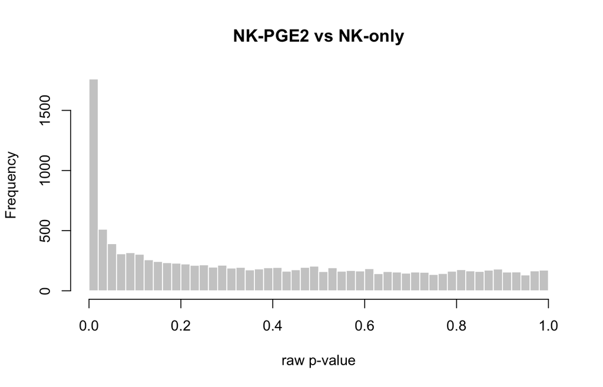

```r
hist(res_pge2$pvalue, breaks = 50, col = "grey80", border = "white",
     main = "NK-PGE2 vs NK-only", xlab = "raw p-value")
```

Plot the **raw** p-values, not the adjusted ones. Genes that did not change produce p-values spread evenly between 0 and 1; genes that did pile up near zero. So the healthy shape is flat with a spike at the left, which is what this is.

| Shape | What it means |
| --- | --- |
| Flat, spike at 0 | Healthy |
| Flat, no spike | Nothing detected |
| Hill in the middle | Model is wrong, often a missing covariate |
| Spike at 1 | Over-conservative filtering |

The hill is the one to watch for. It is the clearest signal that something systematic has not been modelled.

## 3.8 MA plot

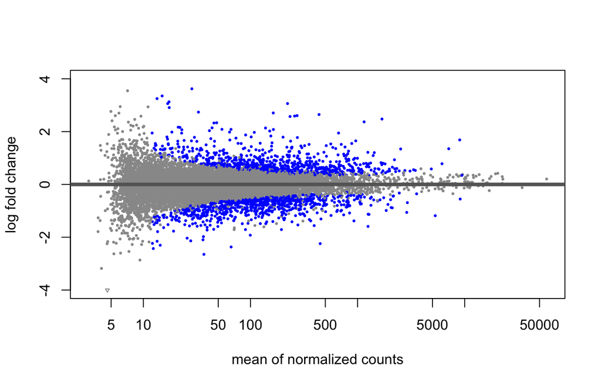

```r
# DESeq2:: spelled out: limma also has a plotMA, and if limma is loaded
# it masks this one and silently plots something else
DESeq2::plotMA(res_pge2, ylim = c(-4, 4))
```

Mean expression across the bottom on a log scale, fold change up the side, significant genes in blue.

Three things to check:

**Is the cloud centred on zero?** This is the main one. If the bulk of genes sits visibly above or below the line, normalization has not worked and the samples are not on a common scale.

**Is there a funnel at the left?** Expected, and the reason not to trust fold changes of low-count genes. Its absence would be stranger than its presence.

**Where do the significant genes sit?** Spread across the expression range is healthier than all of them crammed at the low end, where the measurements are least reliable.

**Shrinking fold changes**

`lfcShrink()` pulls unreliable fold changes toward zero while leaving well-supported ones alone:

```r
res_shrunk <- lfcShrink(dds, coef = "condition_NK.PGE2_vs_NK.only",
                        type = "apeglm")
```

It does not change p-values, only the effect size estimate. Worth using whenever you rank genes by fold change, or the top of your list will be low-count noise.

## 3.9 Volcano

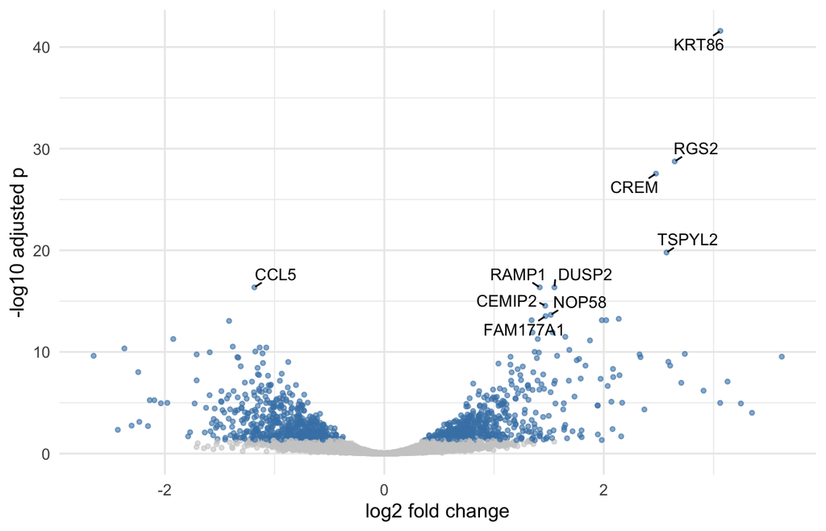

```r
volc <- as.data.frame(res_pge2) |>
  tibble::rownames_to_column("gene") |>
  filter(!is.na(padj)) |>
  mutate(sig = padj < 0.05)

# the ten most significant genes, to label
top10 <- volc |> arrange(padj) |> head(10)

ggplot(volc, aes(x = log2FoldChange, y = -log10(padj))) +
  geom_point(aes(colour = sig), alpha = 0.6, size = 1) +
  ggrepel::geom_text_repel(data = top10, aes(label = gene),
                           size = 3.5, min.segment.length = 0,
                           max.overlaps = Inf, seed = 1) +
  scale_colour_manual(values = c("FALSE" = "grey80", "TRUE" = "steelblue"),
                      guide = "none") +
  labs(x = "log2 fold change", y = "-log10 adjusted p") +
  theme_minimal(base_size = 12)
```

Labelling the top genes turns the plot from a shape into a result. CREM, RGS2 and DUSP2 are all visible near the top.

# 4 Does the contamination matter?

Checking the samples found K562 carryover in two arms. This is the comparison that involves one of them.

```r
res_k562 <- results(dds, contrast = c("condition", "NK-K562", "NK-only"))

sum(res_k562$padj < 0.05, na.rm = TRUE)
```

```
#> [1] 1713
```

```r
as.data.frame(res_k562) |>
  tibble::rownames_to_column("gene") |>
  filter(!is.na(padj)) |>
  arrange(padj) |>
  select(gene, log2FoldChange, padj) |>
  head(10)
```

```
#>          gene log2FoldChange          padj
#> 1       NR4A3       4.048647 2.145362e-142
#> 2        IFNG       3.930579 5.027962e-117
#> 3        CCL3       3.017176 1.806901e-107
#> 4      NFKBID       3.606875  3.372532e-91
#> 5       NR4A2       3.379491  3.372532e-91
#> 6      RILPL2       3.332902  1.232128e-85
#> 7  AC243829.4       3.367033  5.313166e-78
#> 8       CRTAM       3.799301  2.139254e-73
#> 9        EGR2       3.563967  8.415589e-70
#> 10       XCL1       3.357157  3.154377e-68
```

`IFNG` is interferon gamma, `TNF` tumor necrosis factor, `CCL3` and `XCL1` chemokines, `FASLG` kills target cells, and the `NR4A` and `EGR` families are immediate-early activation genes. This is what an NK cell does on meeting a target it recognizes.

## 4.1 Where did the carryover genes end up?

```r
k562_genes <- c("HBG1", "HBG2", "HBZ", "HBA1", "HBA2", "HBB",
                "GATA1", "GYPA", "GYPB", "KLF1")

as.data.frame(res_k562) |>
  tibble::rownames_to_column("gene") |>
  filter(!is.na(padj)) |>
  arrange(padj) |>
  mutate(rank = row_number()) |>
  filter(gene %in% k562_genes) |>
  select(gene, rank, log2FoldChange, padj)
```

```
#>     gene  rank log2FoldChange         padj
#> 1   HBG1   115     3.83746874 3.876932e-13
#> 2   HBG2   141     4.19523116 4.803913e-11
#> 3    HBZ   199     4.02413327 1.373334e-08
#> 4   GYPB   266     3.30610309 5.655232e-07
#> 5   HBA1   285     3.06828734 1.041404e-06
#> 6   HBA2   668     3.34566333 7.392505e-04
#> 7  GATA1   735     3.08883863 1.281706e-03
#> 8   KLF1  1130     3.15314891 9.596931e-03
#> 9   GYPA  1424     3.32328174 2.580727e-02
#> 10   HBB 11297    -0.05709673 9.891634e-01
```

Significant, with large fold changes, but the best rank is around 115 out of 11,500. Present, real, and well below the biology.

Note `HBB` near the bottom — adult globin, the one K562 does not make.

The same genes in the PGE2 comparison, where no K562 was present:

```r
as.data.frame(res_pge2) |>
  tibble::rownames_to_column("gene") |>
  filter(gene %in% k562_genes) |>
  select(gene, log2FoldChange, padj) |>
  arrange(padj)
```

```
#>     gene log2FoldChange      padj
#> 1   HBA1     -0.8286611 0.4484167
#> 2   HBG1     -0.6196110 0.6179541
#> 3    HBZ      0.3858081 0.7822909
#> 4   GYPB      0.3026334 0.8454564
#> 5   HBA2     -0.2818016 0.9065308
#> 6   HBG2     -0.1282698 0.9349359
#> 7  GATA1     -0.4236714        NA
#> 8   GYPA     -0.4512382        NA
#> 9    HBB      0.3911904        NA
#> 10  KLF1      0.9907817        NA
```

Nothing significant. The signal appears only where K562 was in the well.

**What this does and does not tell you**

The contamination is real and it did not change the headline. That is the useful version of the lesson: contamination does not automatically ruin an experiment, but you only know whether it did by looking.

It would still mislead anyone reading down the gene list without the QC — “NK cells upregulate fetal hemoglobin on target contact” is there to be found.

**Could you adjust for it as a covariate?**

Only if the contamination varies **within** a condition.

Here it does not: the erythroid score correlates 0.93 with condition, because only the K562 arms have any. Putting both in the model asks it to separate two things that move together, which removes the effect you are measuring.

In experiments where some wells came out dirtier than others, the score carries information the condition label does not, and a covariate helps. That is the common case in co-culture work.

# 5 Was the design worth it?

`~ replicate + condition` has been used throughout without justification. Test it by fitting the same data without the replicate term.

```r
# this refits the whole model, so it takes about 30 seconds
dds_nb <- DESeqDataSetFromMatrix(counts[keep, ], design_df, ~ condition)
dds_nb <- DESeq(dds_nb)
res_nb <- results(dds_nb, contrast = c("condition", "NK-PGE2", "NK-only"))

c(blocked   = sum(res_pge2$padj < 0.05, na.rm = TRUE),
  unblocked = sum(res_nb$padj   < 0.05, na.rm = TRUE))
```

```
#>   blocked unblocked
#>      1176       939
```

About 1,176 significant genes with the block, 939 without. Roughly 25% more, from one word in the formula, on identical data.

Blocking removes consistent replicate-to-replicate differences from the noise estimate, so real effects stand out. It is the cheapest improvement available in the whole analysis — and it only works because the experiment was designed with every condition present in every batch.

The design decision made at the bench is what made it possible.

# Appendix: how the sample sheet was made

`data/sample_sheet.csv` was not supplied by the authors. It was built from the count matrix column names, which look like `NK-PGE2-BR1.fastq`. Removing the `-BR1.fastq` ending leaves the condition; pulling out the `BR1` part gives the replicate.

```r
library(stringr)

tibble(sample = colnames(counts)) |>
  mutate(
    # drop the "-BR1.fastq" ending, leaving the condition
    condition = str_remove(sample, "-BR[0-9]+\\.fastq$"),
    # pull out just the BR number
    replicate = str_extract(sample, "BR[0-9]+")
  ) |>
  write.csv("data/sample_sheet.csv", row.names = FALSE)
```

The GEO accession column was added by hand from the series page.

If you reuse public data, expect to do some version of this. Deposited metadata is often thinner than the experiment that produced it, and the design frequently has to be read back out of sample names.

# Takeaways

1. **Counts in, not TPM.** The size of a count is information the model needs.
2. **Check samples before results.** Sex genes and cell-type markers take five minutes.
3. **Do not filter before a contamination check.** Filtering removes the evidence.
4. **Tell the model the design.** One word gave 25% more power here.
5. **Check known biology appears.** CREM was the positive control and it turned up unprompted.
6. **Find contamination, then judge it.** Present is not the same as fatal.

# Where to learn more

- DESeq2 vignette — https://bioconductor.org/packages/DESeq2
- edgeR user guide — https://bioconductor.org/packages/edgeR
- RNAseq123 workflow — https://bioconductor.org/packages/RNAseq123
- Design matrices guide — https://f1000research.com/articles/9-1444
- nf-core/rnaseq docs — https://nf-co.re/rnaseq
- Bioconductor support — https://support.bioconductor.org

Everything here runs on a laptop, and the repository has the data and the code. The fastest way to learn this is to run it again on a dataset you care about.

# Data credit

Data from GEO accession GSE191074, generated and deposited by the authors of:

> Rothfuß C, Baumann T, Donakonda S, et al. Two-layered immune escape in AML is overcome by Fcγ receptor activation and inhibition of PGE2 signaling in NK cells. *Blood* 2025;145(13):1395–1406. doi:10.1182/blood.2024025706

The contamination described here is a normal technical feature of co-culture experiments, not a criticism of that work.